# Likelihood Homework

Biol 607

## Puffers!

Let’s look at the [pufferfish data](http://biol607.github.io/homework_2018/data/16q11PufferfishMimicry%20Caley%20&%20Schluter%202003.csv) with likelihood!

**1. Grid Sampling!** Based on Friday’s lab, load up the pufferfish data and use grid sampling to find the MLE of the slope, intercept and residual SD of this model. Feel free to eyeball results from an `lm()` fit to get reasonable values. Try not to do this for a grid of more than ~100K points (more if you want!). It’s ok to be coarse. Compare to lm.

```r
library(tidyr)
library(dplyr)
puffer <- read.csv('../data/16q11PufferfishMimicry Caley & Schluter 2003.csv')

#for parameter values
puffer_lm <- lm(predators ~ resemblance, data = puffer)
summary(puffer_lm)
```

```
##
## Call:
## lm(formula = predators ~ resemblance, data = puffer)
##
## Residuals:
##     Min      1Q  Median      3Q     Max
## -4.9142 -2.1563  0.0858  1.5884  6.0858
##
## Coefficients:
##             Estimate Std. Error t value Pr(>|t|)
## (Intercept)   1.9247     1.5064   1.278    0.218
## resemblance   2.9895     0.5714   5.232 5.64e-05 ***
## ---
## Signif. codes:  0 '***' 0.001 '**' 0.01 '*' 0.05 '.' 0.1 ' ' 1
##
## Residual standard error: 3.053 on 18 degrees of freedom
## Multiple R-squared:  0.6033, Adjusted R-squared:  0.5812
## F-statistic: 27.37 on 1 and 18 DF,  p-value: 5.638e-05
```

```r
lik_fun <- function(slope, intercept, resid_sd){
  #data generating process
  predators_fit <- intercept + slope * puffer$resemblance

  #likelihood
  sum(dnorm(puffer$predators, predators_fit, resid_sd, log=TRUE))


}

grid_samp <- crossing(intercept = seq(0.5, 2.5, .05),
                      slope = seq(2,4,.05),
                      resid_sd = seq(2.9, 3.1, .01)) %>%
  rowwise() %>%
  mutate(logLik = lik_fun(slope, intercept, resid_sd)) %>%
  ungroup()

#the ML estimates are
grid_samp %>% filter(logLik == max(logLik))
```

```
## # A tibble: 1 x 4
##   intercept slope resid_sd logLik
##       <dbl> <dbl>    <dbl>  <dbl>
## 1       1.9     3      2.9  -49.6
```

```r
puffer_lm
```

```
##
## Call:
## lm(formula = predators ~ resemblance, data = puffer)
##
## Coefficients:
## (Intercept)  resemblance
##       1.925        2.989
```

**2. Surfaces!** Filter the dataset to the MLE of the SD. Plot the surface for the slope and intercept in whatever way you find most compelling. You might want to play around with zooming in to different regions, etc. Have fun!

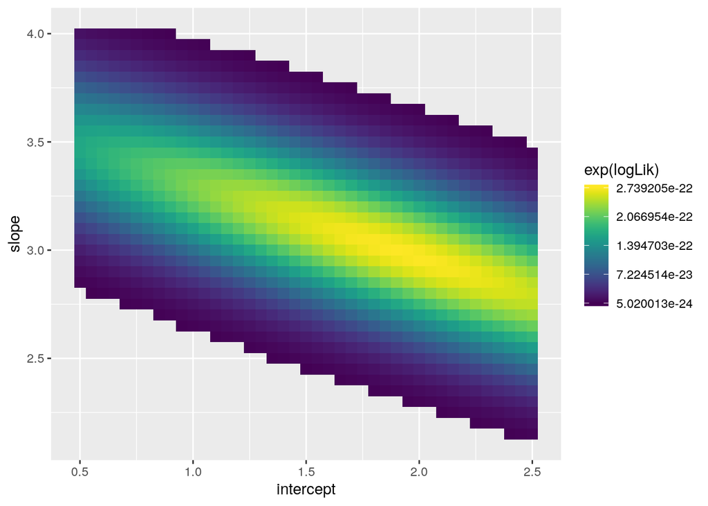

```r
library(ggplot2)
library(viridis)
ggplot(grid_samp %>% filter(resid_sd == 2.9)
       %>%   filter(logLik >  max(logLik) - 4),
       aes(x = intercept, y = slope, fill = exp(logLik))) +
  geom_raster() +
  scale_fill_viridis()
```

**3. GLM!** Now, compare those results to results from glm. Show the profiles and confidence intervals from `glm()` for the slope and intercept.

```r
puffer_glm <- glm(predators ~ resemblance, data = puffer,
                 family = gaussian(link = "identity"))

library(profileModel)

prof <- profileModel(puffer_glm,
                     objective = "ordinaryDeviance",
                     quantile = qchisq(0.95, 1))
```

```
## Preliminary iteration .. Done
##
## Profiling for parameter (Intercept) ... Done
## Profiling for parameter resemblance ... Done
```

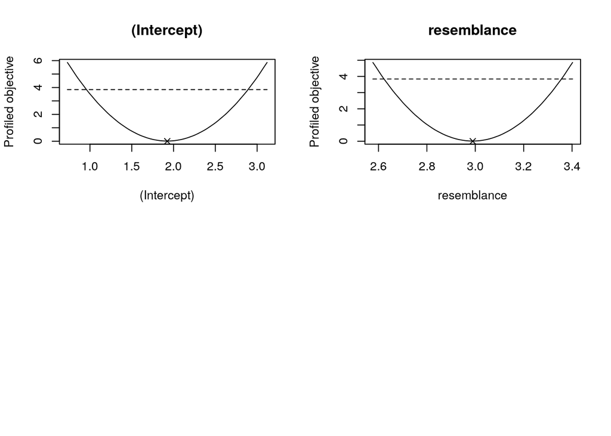

```r
plot(prof)
```

```r
confint(puffer_glm)
```

```
##                 2.5 %   97.5 %
## (Intercept) -1.027828 4.877215
## resemblance  1.869537 4.109447
```

**4. Get Outside of GLM!** So, often, we have more complex models than the above. There are a variety of optimizers out there, and packages for accessing them. One of the best is `bbmle` by Ecologist Ben Bolker (whose dad is emeritus at UMB in computer science! Go visit him! He’s fantastic!)

Load up `'bbmle` and try out `mle2`. It’s a bit different, in that the first argument is a function that *minimizes* the log likelihood (not maximizes). The second argument is a list of start values - e.g. `list(slope = 2, intercept = 5, resid_sd = 2)`. Try and fit your model with `mle2` using start values close to the actual estimates. Look at the summary and plot the profile. Note, you might get a lot of errors because it will try impossible values of your residual SD. Also, note thatyou’ll have to rewrite your likelihood function to return the negative log likelihood (or write a wrapper that does so). A small thing

```r
library(bbmle)
min_lik_fun <- function(slope, intercept, resid_sd) -1*lik_fun(slope, intercept, resid_sd)

puffer_mle2 <- mle2(min_lik_fun,
                    start = list(slope = 1.9, intercept = 1, resid_sd = 3))

summary(puffer_mle2)
```

```
## Maximum likelihood estimation
##
## Call:
## mle2(minuslogl = min_lik_fun, start = list(slope = 1.9, intercept = 1,
##     resid_sd = 3))
##
## Coefficients:
##           Estimate Std. Error z value     Pr(z)
## slope      2.98957    0.54219  5.5138 3.511e-08 ***
## intercept  1.92461    1.42938  1.3465    0.1782
## resid_sd   2.89707    0.45820  6.3228 2.569e-10 ***
## ---
## Signif. codes:  0 '***' 0.001 '**' 0.01 '*' 0.05 '.' 0.1 ' ' 1
##
## -2 log L: 99.29798
```

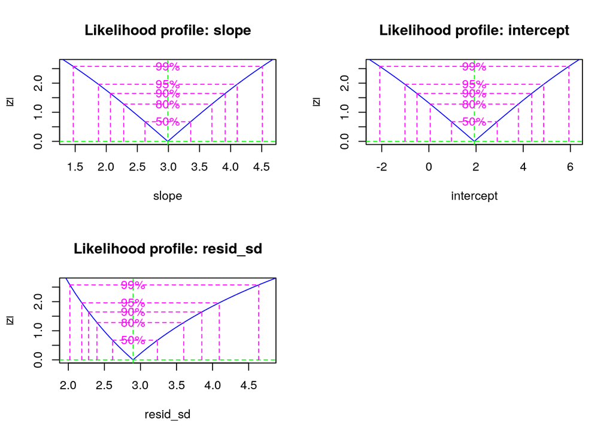

```r
plot(profile(puffer_mle2))
```

**5. Start values!** What happens if you start with start values *very* far away from the initial values. Failing here is fine. But what do you think is happening, and what does this say about the value of start values?

```r
 mle2(min_lik_fun,
                    start = list(slope = 100, intercept = -100, resid_sd = 0.1))
```

```
##
## Call:
## mle2(minuslogl = min_lik_fun, start = list(slope = 100, intercept = -100,
##     resid_sd = 0.1))
##
## Coefficients:
##      slope  intercept   resid_sd
##   44.50093 -114.84696  294.43794
##
## Log-likelihood: -132.41
##
## Warning: optimization did not converge (code 1: )
```

```r
#This produces a convergence error - the algorithm never converges.
#other possibilities are that the whole thing fails because of bad sd values
#or we get convergence and they don't notice anything
#Start values are very important and can alter the outcome of your models. Try either "good" start values, or try multiple ones and make sure your results conferge.
```

**6. Algorithms!** By default, `mle2` uses the Nelder-Mead algorithm via the `optim` function. What happens if you add an `method` argument to “SANN” or “L-BFGS-B” (and for the later, which is bounded sampling, give it a `lower` argument for your residual value, so it’s always positive). See `?optim` for some more guidance. Do these both converge to the same value? Based on their profiles, do you trust them? (Note, Simulated annealing takes a looooong time. Go have a cuppa while the profile for that one runs).

```r
puffer_sann <- mle2(min_lik_fun,
                    start = list(slope = 1.9, intercept = 1, resid_sd = 3),
                    method = "SANN")

summary(puffer_sann)
```

```
## Maximum likelihood estimation
##
## Call:
## mle2(minuslogl = min_lik_fun, start = list(slope = 1.9, intercept = 1,
##     resid_sd = 3), method = "SANN")
##
## Coefficients:
##           Estimate Std. Error z value     Pr(z)
## slope      3.00290    0.54391  5.5209 3.372e-08 ***
## intercept  1.85902    1.43401  1.2964    0.1948
## resid_sd   2.90614    0.46182  6.2929 3.117e-10 ***
## ---
## Signif. codes:  0 '***' 0.001 '**' 0.01 '*' 0.05 '.' 0.1 ' ' 1
##
## -2 log L: 99.30179
```

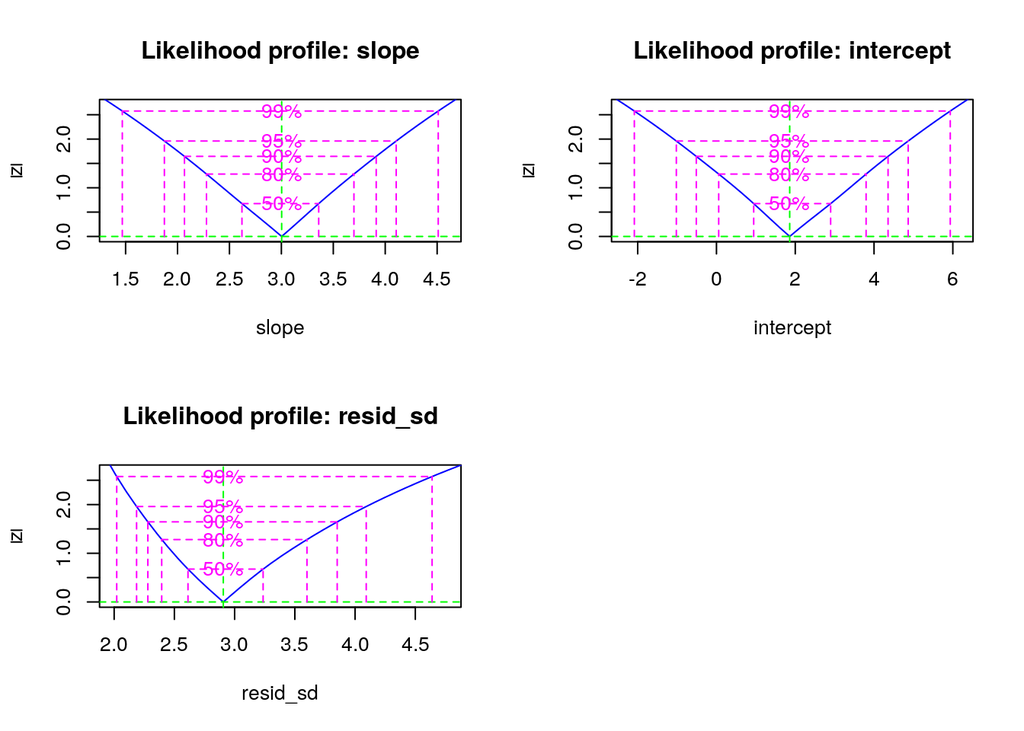

```r
plot(profile(puffer_sann))
```

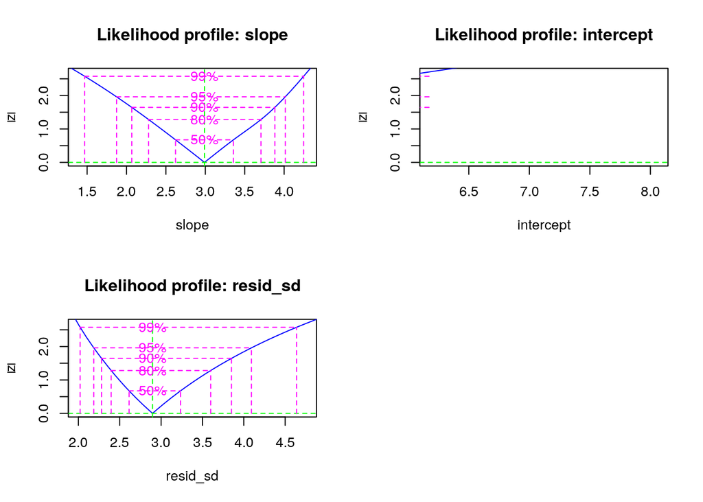

```r
puffer_bfgs <- mle2(min_lik_fun,
                    start = list(slope = 1.9, intercept = 1, resid_sd = 3),
          method = "L-BFGS-B",
          lower=c(resid_sd = 1e-10))

plot(profile(puffer_bfgs))
```

```r
summary(puffer_bfgs)
```

```
## Maximum likelihood estimation
##
## Call:
## mle2(minuslogl = min_lik_fun, start = list(slope = 1.9, intercept = 1,
##     resid_sd = 3), method = "L-BFGS-B", lower = c(resid_sd = 1e-10))
##
## Coefficients:
##           Estimate Std. Error z value     Pr(z)
## slope      2.98948    0.54209  5.5147 3.494e-08 ***
## intercept  1.92473    1.42911  1.3468     0.178
## resid_sd   2.89652    0.45798  6.3246 2.540e-10 ***
## ---
## Signif. codes:  0 '***' 0.001 '**' 0.01 '*' 0.05 '.' 0.1 ' ' 1
##
## -2 log L: 99.29798
```